# LAB3 ejercicios

Laura Sudupe

31/10/2020

EJERCICIO 2. Consideremos ahora el conjunto de datos anorexia del paquete MASS y realicemos algunas consultas sobre estos datos, por ejemplo, de los 72 pacientes tratados, ¿cuántos de ellos han perdido peso después de realizar algún tratamiento?

```r
library(MASS)
data("anorexia")
prewt <- c(anorexia$Prewt)
postwt <- c(anorexia$Postwt)
result <- c(postwt - prewt)
dif_peso <- 0

for(i in 1:length(result))
if (result[i] < 0)
  dif_peso <- dif_peso + 1

print(dif_peso)
```

```
## [1] 29
```

EJERCICIO 3. A partir del conjunto de datos anorexia, calculad el porcentaje de pacientes que han realizado cada tipo de tratamiento.

```r
table <- data.frame(anorexia)
cont <- 0
CBT <- 0
FT <- 0

tratamiento <- c(anorexia$Treat)

for(i in 1:length(tratamiento))
  if (anorexia$Treat[i]== "Cont") {
    cont <- cont + 1
} else
  if (anorexia$Treat[i]== "CBT") {
    CBT <- CBT + 1
} else {
    FT <- FT + 1
}

porcentaje_cont <- cont/length((tratamiento))
porcentaje_CBT <- CBT/length((tratamiento))
porcentaje_FT <- FT/length((tratamiento))
porcentaje_CBT
```

```
## [1] 0.4027778
```

```r
porcentaje_cont
```

```
## [1] 0.3611111
```

```r
porcentaje_FT
```

```
## [1] 0.2361111
```

EJERCICIO 4. A partir del conjunto de datos birthwt, calculad cuántos recién nacidos con un Peso inferior a 2.600 gramos corresponden a madres menores de 20 años y fumadoras.

```r
data("birthwt")


count <- 0
bwt <- c(birthwt$bwt)

for(i in 1:length(bwt))
  if (birthwt$age[i] < 20)
  if (birthwt$bwt[i] < 2600)
  if (birthwt$smoke[i] == 1) {
    count <- count + 1
  }
count
```

```
## [1] 7
```

EJERCICIO 5. A partir del conjunto de datos birthwt del paquete MASS, guardad en un vector los pesos de los recién nacidos cuyas madres tengan menos de 20 años. Calculad la media y representad gráficamente este vector (por ejemplo, un diagrama de puntos).

```r
#definimos el vector que guardara los pesos
bwt_c <- c()
j <- 1

#deginimos la función
F_bwt <- function(){
  for (i in 1:length(birthwt$bwt))
    if (birthwt$age[i] < 20) {
      bwt_c[j] <- birthwt$bwt[i]
      j <- j + 1
    }
  return (bwt_c)
  }

bwt_c_edad <- F_bwt()
bwt_c_edad
```

```
##  [1] 2523 2600 2637 2722 2733 2769 2769 2778 2906 2920 2920 2977 3062 3062 3062
## [16] 3090 3175 3175 3225 3225 3374 3374 3402 3572 3572 3629 3643 3651 3651 3756
## [31] 3856 3860 3884 3941 3997 4238 1885 1899 2082 2084 2125 2225 2282 2296 2353
## [46] 2381 2414 2438 2466 2495 2495
```

```r
#calculamos la media y el grafico
mean(bwt_c_edad)
```

```
## [1] 2973.529
```

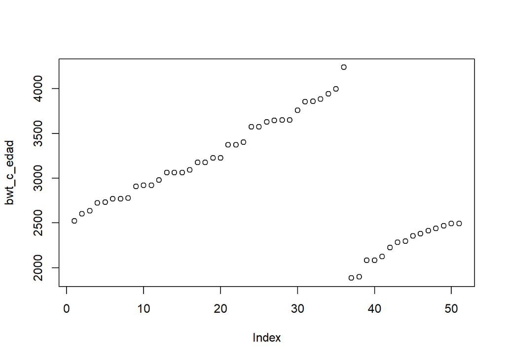

```r
plot(bwt_c_edad)
```

EJERCICIO 7. A partir del ejercicio 5 propuesto anteriormente, definid una función que calcule la media y otra función que realice la representación gráfica de los datos propuestos en el enunciado.

```r
F_mean <- function(x) {
  return (mean(x))
}
F_plot <- function(y) {
  return (plot(y))
}
F_mean(bwt_c_edad)
```

```
## [1] 2973.529
```

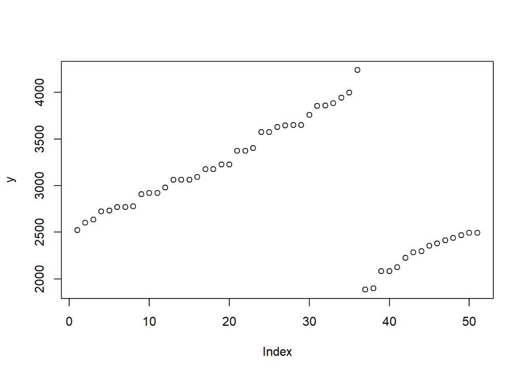

```r
F_plot(bwt_c_edad)
```

EJERCICIO 8. A partir del conjunto de datos anterior, resolved las siguientes consultas: a) Mostrad la media del factor Ozone.

```r
library(sqldf)
library(RSQLite)
library(dplyr)
db <- "RSQLite"::datasetsDb()
dbListTables(db) #mostramos el conjunto de datos
```

```
##  [1] "BOD"              "CO2"              "ChickWeight"      "DNase"
##  [5] "Formaldehyde"     "Indometh"         "InsectSprays"     "LifeCycleSavings"
##  [9] "Loblolly"         "Orange"           "OrchardSprays"    "PlantGrowth"
## [13] "Puromycin"        "Theoph"           "ToothGrowth"      "USArrests"
## [17] "USJudgeRatings"   "airquality"       "anscombe"         "attenu"
## [21] "attitude"         "cars"             "chickwts"         "esoph"
## [25] "faithful"         "freeny"           "infert"           "iris"
## [29] "longley"          "morley"           "mtcars"           "npk"
## [33] "pressure"         "quakes"           "randu"            "rock"
## [37] "sleep"            "stackloss"        "swiss"            "trees"
## [41] "warpbreaks"       "women"
```

```r
dbReadTable(db, "airquality") #accedemos al conjunto de datos
```

```
##     Ozone Solar.R Wind Temp Month Day
## 1      41     190  7.4   67     5   1
## 2      36     118  8.0   72     5   2
## 3      12     149 12.6   74     5   3
## 4      18     313 11.5   62     5   4
## 5      NA      NA 14.3   56     5   5
## 6      28      NA 14.9   66     5   6
## 7      23     299  8.6   65     5   7
## 8      19      99 13.8   59     5   8
## 9       8      19 20.1   61     5   9
## 10     NA     194  8.6   69     5  10
## 11      7      NA  6.9   74     5  11
## 12     16     256  9.7   69     5  12
## 13     11     290  9.2   66     5  13
## 14     14     274 10.9   68     5  14
```

[output cut: 139 more lines]

```r
colnames(airquality)
```

```
## [1] "Ozone"   "Solar.R" "Wind"    "Temp"    "Month"   "Day"
```

```r
sqldf("SELECT AVG(Ozone) FROM airquality")
```

```
##   AVG(Ozone)
## 1   42.12931
```

```r
head(sqldf("SELECT Ozone, [Solar.R],
           Wind FROM airquality where Month in (5,7)"))
```

```
##   Ozone Solar.R Wind
## 1    41     190  7.4
## 2    36     118  8.0
## 3    12     149 12.6
## 4    18     313 11.5
## 5    NA      NA 14.3
## 6    28      NA 14.9
```

3. Mostrad la información anterior ordenada por Month.

```r
head(sqldf("SELECT Ozone, [Solar.R],
           Wind, Month FROM airquality where Month in (5,7) ORDER BY Month"))
```

```
##   Ozone Solar.R Wind Month
## 1    41     190  7.4     5
## 2    36     118  8.0     5
## 3    12     149 12.6     5
## 4    18     313 11.5     5
## 5    NA      NA 14.3     5
## 6    28      NA 14.9     5
```

4. Mostrad los datos de Wind, agrupados por Month.

```r
head(sqldf("SELECT Wind, Month FROM airquality GROUP BY Month"))
```

```
##   Wind Month
## 1  7.4     5
## 2  8.6     6
## 3  4.1     7
## 4  6.9     8
## 5  6.9     9
```